# Week 6 In-class: LaQuinta

## Introduction

LaQuinta is trying to decide where to locate a new motel. As analysts, your team is tasked with determining which factors are relevant in determing profitability and predicting strong locations for expansion. A group of strategists determined factors worthy of exploration are competition, market awareness, demand generators, socio-economic factors, and location.

In preparation, the company has identified and compiled a variety of potential predictors for profitability (measured via operating margin–Margin–of current hotels). They are:

- Number: Total motel and hotel rooms within a 3 mile radius
- Nearest: Number of miles to closest copmetition
- OfficeSpace: Volume of office space in surrounding community, in 1000s sqft
- Enrollment: Number of college and university students in the community, in 1000s
- Income: Median household income, $1000s
- Distance: Distance (in miles) to the downtown core

## Exploratory Analysis

First, load the data and explore some features of interest.

```r
laquinta <- read_csv("https://raw.githubusercontent.com/jddbucknole/SMB-A/master/LaQuinta.csv")
```

Examine the scatterplots relating the explanatory variables to the response (Margin) as well as the correlation. Include any of the scatter plots you think are of interest and the correlation matrix (using the cor() function). Comment on what you see. Which variables appear to be impactful in predicting margin? Which influence in a positive manner? Negative manner? Is that what you expected?

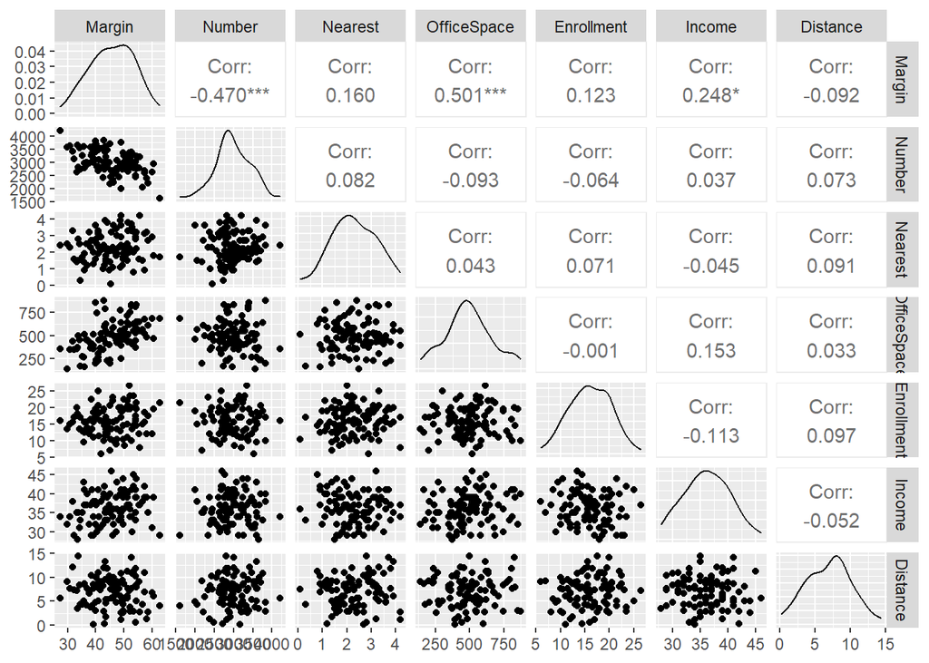

```r
#correlation matrix
#plots of interest
library(GGally)
ggpairs(laquinta)
```

```r
#OfficeSpace has highest correlation and it's positive
```

Office Space has the highest correlation and it’s positive, so the more square footage of Office Spaces nearby would increase margin.

The other highly correlated value was the Number of other hotels (competitors) within a 3 mile radius and since it’s negative, the more competitor hotels would decrease the margin.

This is what we expected but surprised that there wasn’t more correlation with Distance to Downtown and Household Income.

## Simple Linear Regression

Fit a linear model to predict Margin from the single variable that is the **most correlated** with the response. Interpret both coefficients **in context** if they are sensible. If not, explain why not.

```r
#LM for most correlated response
marginmodel <- lm(Margin ~ OfficeSpace, data = laquinta)
summary(marginmodel)
```

```
##
## Call:
## lm(formula = Margin ~ OfficeSpace, data = laquinta)
##
## Residuals:
##      Min       1Q   Median       3Q      Max
## -15.2892  -4.6961   0.3761   4.7261  15.3061
##
## Coefficients:
##             Estimate Std. Error t value Pr(>|t|)
## (Intercept) 34.18846    2.12310  16.103  < 2e-16 ***
## OfficeSpace  0.02347    0.00409   5.737 1.07e-07 ***
## ---
## Signif. codes:  0 '***' 0.001 '**' 0.01 '*' 0.05 '.' 0.1 ' ' 1
##
## Residual standard error: 6.741 on 98 degrees of freedom
## Multiple R-squared:  0.2514, Adjusted R-squared:  0.2438
## F-statistic: 32.92 on 1 and 98 DF,  p-value: 1.072e-07
```

```r
view(laquinta)
```

If there is no square footage of office space within 3 miles, then the margin would be 34%.This makes sense because hotels could have guests staying for other reasons besides work like vacation or non-work travel.

For every thousand square feet of office space the margin goes up 0.02347%. Since office space is per thousand square feet, the small increase still makes sense.

## Model Fitting

Fit a multiple linear regression model to predict Margin from the other predictors. Produce the “best” model according to whatever criteria you choose. After you have finalized your model, report the summary and any requisite diagnostic plots below (only run the final model in this R markdown file).

```r
#Final LM
marginmodelmult <- lm(Margin ~ OfficeSpace + Number + Nearest + Income, data = laquinta)

summary(marginmodelmult)
```

```
##
## Call:
## lm(formula = Margin ~ OfficeSpace + Number + Nearest + Income,
##     data = laquinta)
##
## Residuals:
##      Min       1Q   Median       3Q      Max
## -13.7135  -3.1234   0.0449   4.1846  14.5312
##
## Coefficients:
##              Estimate Std. Error t value Pr(>|t|)
## (Intercept) 41.273150   6.414992   6.434 5.01e-09 ***
## OfficeSpace  0.019607   0.003439   5.702 1.33e-07 ***
## Number      -0.007863   0.001260  -6.238 1.22e-08 ***
## Nearest      1.653650   0.635316   2.603  0.01073 *
## Income       0.399387   0.139886   2.855  0.00528 **
## ---
## Signif. codes:  0 '***' 0.001 '**' 0.01 '*' 0.05 '.' 0.1 ' ' 1
##
## Residual standard error: 5.563 on 95 degrees of freedom
## Multiple R-squared:  0.5058, Adjusted R-squared:  0.485
## F-statistic: 24.31 on 4 and 95 DF,  p-value: 7.23e-14
```

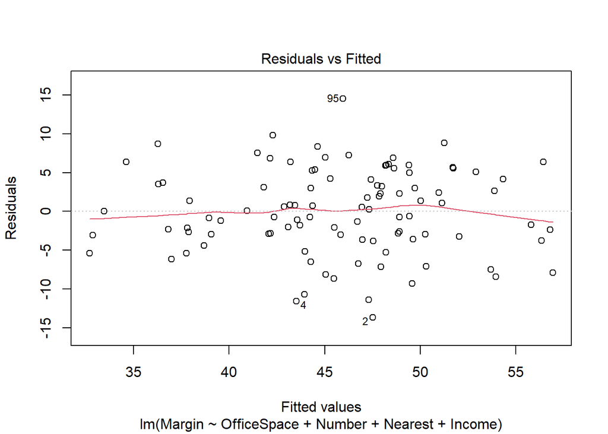

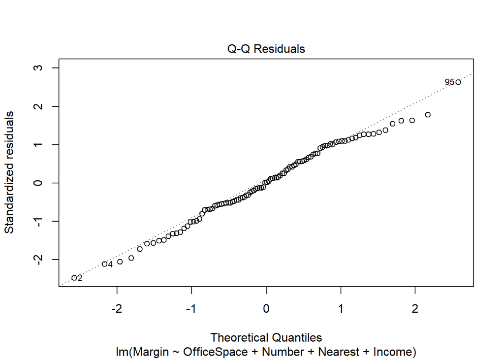

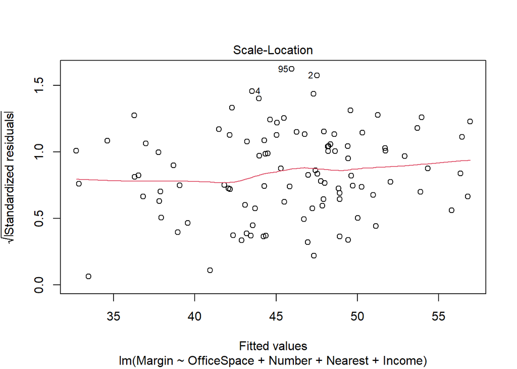

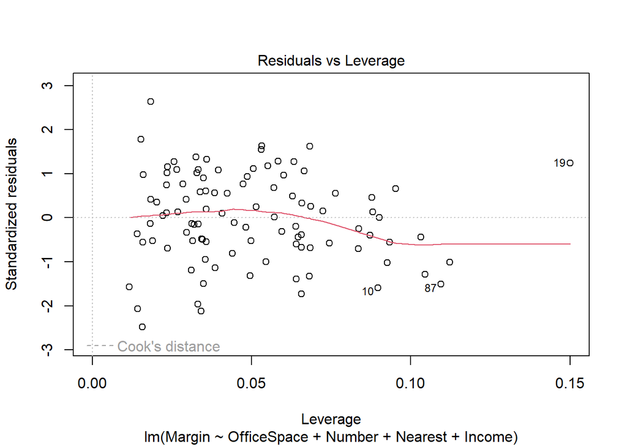

```r
#Diagnostic plots
plot(marginmodelmult)
```

We removed Enrollment and Distance as they did not significantly impact the margin as much as the other variables.

## Conclusion and Recommendations

Discuss why you chose the model you settled on. Focus on the model fit, residuals, significance, etc. This is the most important part of the assignment. Make sure to give concrete recommendations to LaQuinta in context. You should use common business language explaining what factors are relevant without focusing solely on the statistical jargon.

There is a location of interest that has 3815 rooms within 3 miles, the closest hotel is 0.9 miles away, the amount of office space is 476,000 square feet, there is one college and one university with a total enrollment of 24,500, the median income in the area is $35,000, and the distance to the downtown core is 11.2 miles. Form a 95% prediction interval for the operating margin at this location **based on your model**. Profitable inns are defined by those with operating margins greater than 50%. Would you recommend this site?

```r
#Code to find prediction interval
marginmodelmult <- lm(Margin ~ OfficeSpace + Number + Nearest + Income, data = laquinta)
predinterval <- data.frame(Number = 3815, Nearest = 0.9, OfficeSpace = 476, Income = 35)
predict(marginmodelmult, newdata = predinterval, interval = "predict")
```

```
##        fit      lwr     upr
## 1 36.07763 24.60916 47.5461
```

The predictors for profitability were identified to be strongest with OfficeSpace - so if you are picking a hotel location to focus on areas with higher Office Space square footage, less number of hotels/motels within 3 mile radius, further distance from competitors, and higher median household income in the area would increase profitability.

No, we wouldn’t recommend this site because the upper limit of this model is 47.5% which is not statistically significant (at 95% prediction interval) since profitable inns are defined by operating margins greater than 50%.

However, if they find an alternative location with less rooms within a 3 mile radius and more office space square footage, they would have a greater chance of being profitable at over 50%.